# Looking into Inter-Variable Relationships and Classification with Five Predictor Models in the Bank Marketing Dataset to Determine Subscribed Status of Clients

#### Mosaic Plot Between Subscribed Status and Default:

```r
y.default.cont = xtabs(~subscribed+default, bank.2)
```

```r
print(y.default.cont)
```

```
##           default
## subscribed   no  yes
##        no  2913    1
##        yes  402    0
```

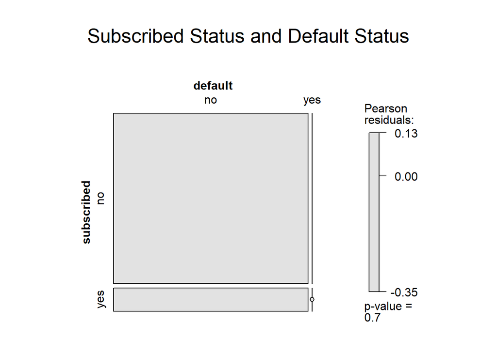

```r
mosaic(x= y.default.cont,
           main="Subscribed Status and Default Status",
           xlab="Subscribed Status", ylab="Default Status",
           shade = T, legend=T)
```

Observing the mosaic plot above, it appears Subscribed status and default status are independent.

#### Mosaic Plot Between Subscribed status and Education Status:

```r
y.education.cont = xtabs(~subscribed+education, bank.2)
```

```r
print(y.education.cont)
```

```
##           education
## subscribed basic.4y basic.6y basic.9y high.school illiterate
##        no       391      211      531         824          1
##        yes       38       17       43          97          0
##           education
## subscribed professional.course university.degree
##        no                  470              1099
##        yes                  65               165
```

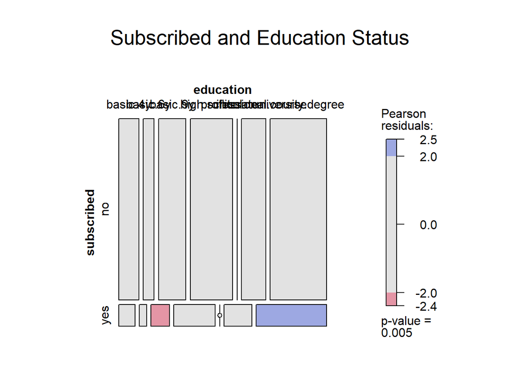

```r
mosaic(x= y.education.cont,
           main="Subscribed and Education Status",
           xlab="Subscribed Status", ylab="Education Status",
           shade = T, legend=T)
```

According to the results of the mosaic plot, the variables subscribed status and education status appear to have a relationship. Based on the mosaic plot we could reject the assumption that subscribed status (y) and education status are independent, but caution would be needed given that the approximation fo the Chi-Squared test earlier may have been misleading. This will have to be taken into consideration for the models developed later.

#### Mosaic Plot Between Subscribed Status and Previous.contact Variable:

```r
y.prev.contact.cont = xtabs(~subscribed+previous.contact, bank.2)
```

```r
print(y.prev.contact.cont)
```

```
##           previous.contact
## subscribed    0    1
##        no  3608   60
##        yes  351  100
```

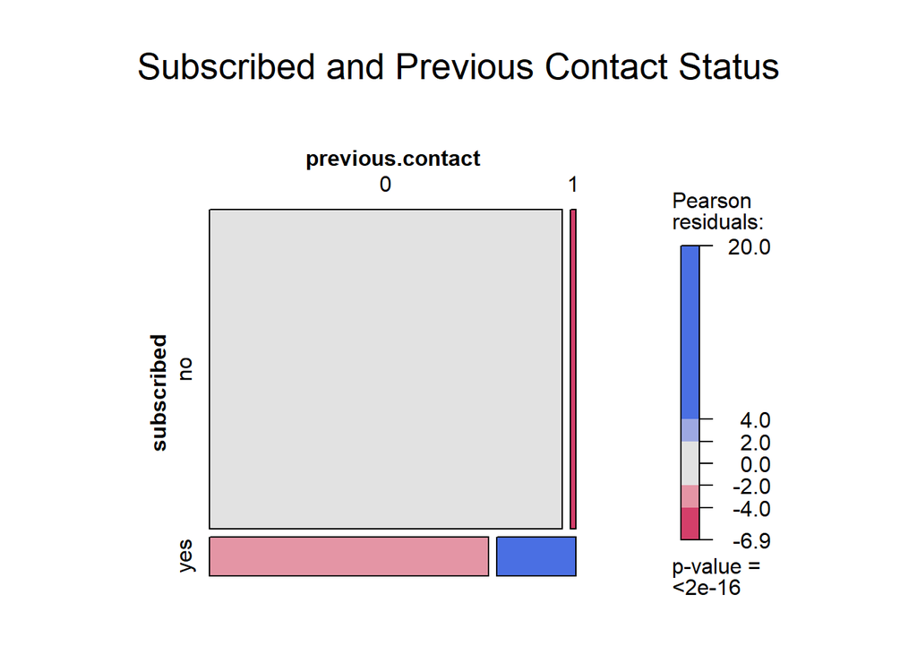

```r
mosaic(x = y.prev.contact.cont,
           main="Subscribed and Previous Contact Status",
           xlab="Subscribed Status", ylab="Previous Contact Status",
           shade = T, legend=T)
```

The results form the mosaic plot demonstrate that there is some relationship between the variables of subscribed status (y) and previous.contact. In the context of these two variables, we can reject the null hypothesis that they are independent. Looking at the mosaic plot, far fewer persons who were previously contacted and did not subscribe to a term deposit as would be expected if the two variables maintained independence. Additionally, more people who were previously contacted and did subscribe to a term deposit than would be expected if the two variables maintained independence.

# Modeling Results

## Training, Validating and Testing Models for Statistical Learning

11. Use at least one statistical learning technique (linear regression, K-Nearest Neighbors, logistic regression, decision trees, random forests) to model the outcome variable(s) that upu identified in Part II of the project as functions of the predictor.factor variables. Report a summary of your model(s) describing the qualityt of the model as well as hoe the predictors affect/correlate to the outcome(s) (for example, in linear regression, the estimates of coefficients show this correlation)

## Logitstic Regression Model Composed All Variables From Research Question 2

Relevant Features: emp.var.rate, loan, default status, education status, campaign, previous.contact

Response variable: Subscription status (y)

Note that Kappa is used as the metric for caret due to the imbalanced classes of the Subsciption status.

```r
bank.3 = bank.2 %>% dplyr::select(., emp.var.rate, loan,
                          default, education, campaign,
                          previous.contact, subscribed) %>%
  na.omit() %>%
  mutate(., subscribed = factor(subscribed),
         default = factor(default),
         education = factor(education),
         loan=factor(loan),
         campaign = as.numeric(campaign))
```

```r
set.seed(10)
data.part.ind = createDataPartition(bank.3$subscribed,
                                    times = 1, p =0.7, list=FALSE)
bank.3.train = bank.3[data.part.ind,] # Get the training data
bank.3.test = bank.3[-data.part.ind,] # get the testing data
bank.3.train.preproc = preProcess(bank.3.train,
                                  method =c("center","scale")) #Establishing
# preprocessing transformations
bank.3.train_preproc_convert = data.frame(
  predict(bank.3.train.preproc, bank.3.train)) # Preprocessing
bank.3.test_preproc_convert = data.frame(
  predict(bank.3.train.preproc, bank.3.test)) # Preprocessing
```

```r
set.seed(10)
cluster_1 <- makeCluster(3)
registerDoSNOW(cluster_1)
all.rel.feat.glm_processing = train(
  x = bank.3.train_preproc_convert[,-7],
  y = bank.3.train_preproc_convert[,7],
  #form = subscribed ~ .,
  #data = bank.3.train_preproc_convert,
  trControl = trainControl(method="cv", repeats = 10),
  method = "glm",
  family="binomial",
  na.action=na.omit,
  metric = "Kappa"
)
stopCluster(cluster_1)
```

```r
all.rel.feat.glm_processing$results
```

```
##   parameter Accuracy Kappa AccuracySD KappaSD
## 1      none    0.892  0.28    0.00852  0.0799
```

```r
all.rel.feat.glm_processing$finalModel
```

```
##
## Call:  NULL
##
## Coefficients:
##                  (Intercept)                  emp.var.rate
##                      -2.7028                       -0.6785
##                      loanyes                    defaultyes
##                      -0.1688                      -11.2501
##            educationbasic.6y             educationbasic.9y
##                       0.3278                        0.0507
##         educationhigh.school           educationilliterate
##                       0.3313                      -12.0156
## educationprofessional.course    educationuniversity.degree
##                       0.5387                        0.4119
##                     campaign             previous.contact1
##                      -0.1171                        1.9760
##
## Degrees of Freedom: 2182 Total (i.e. Null);  2171 Residual
## Null Deviance:       1600
## Residual Deviance: 1350  AIC: 1380
```

Next we take a look at the resulting summary for the model:

```r
summary(all.rel.feat.glm_processing$finalModel)
```

```
##
## Call:
## NULL
##
## Deviance Residuals:
##    Min      1Q  Median      3Q     Max
## -1.670  -0.511  -0.339  -0.292   2.713
##
## Coefficients:
##                              Estimate Std. Error z value Pr(>|z|)
## (Intercept)                   -2.7028     0.2824   -9.57   <2e-16 ***
## emp.var.rate                  -0.6785     0.0743   -9.13   <2e-16 ***
## loanyes                       -0.1688     0.1972   -0.86     0.39
## defaultyes                   -11.2501   535.4112   -0.02     0.98
## educationbasic.6y              0.3278     0.4349    0.75     0.45
## educationbasic.9y              0.0507     0.3584    0.14     0.89
## educationhigh.school           0.3313     0.3116    1.06     0.29
## educationilliterate          -12.0156   535.4113   -0.02     0.98
## educationprofessional.course   0.5387     0.3294    1.64     0.10
## educationuniversity.degree     0.4119     0.2994    1.38     0.17
## campaign                      -0.1171     0.1054   -1.11     0.27
## previous.contact1              1.9760     0.2305    8.57   <2e-16 ***
## ---
## Signif. codes:  0 '***' 0.001 '**' 0.01 '*' 0.05 '.' 0.1 ' ' 1
##
## (Dispersion parameter for binomial family taken to be 1)
##
##     Null deviance: 1602.2  on 2182  degrees of freedom
## Residual deviance: 1352.1  on 2171  degrees of freedom
## AIC: 1376
##
## Number of Fisher Scoring iterations: 12
```

```r
all.rel.feat.glm_predictions =predict(all.rel.feat.glm_processing$finalModel,
                                      bank.3.test_preproc_convert[,-c(7)])
all.rel.feat.glm_predictions = ifelse(all.rel.feat.glm_predictions >= 0.5, "yes", "no")
```

```r
confusionMatrix(factor(all.rel.feat.glm_predictions),
                factor(bank.3.test_preproc_convert[,c(7)]),
                positive = "yes", mode ="everything")
```

```
## Confusion Matrix and Statistics
##
##           Reference
## Prediction  no yes
##        no  816  94
##        yes   7  17
##
##                Accuracy : 0.892
##                  95% CI : (0.87, 0.911)
##     No Information Rate : 0.881
##     P-Value [Acc > NIR] : 0.169
##
##                   Kappa : 0.219
##
##  Mcnemar's Test P-Value : <2e-16
##
##             Sensitivity : 0.1532
##             Specificity : 0.9915
##          Pos Pred Value : 0.7083
##          Neg Pred Value : 0.8967
##               Precision : 0.7083
##                  Recall : 0.1532
##                      F1 : 0.2519
##              Prevalence : 0.1188
##          Detection Rate : 0.0182
##    Detection Prevalence : 0.0257
##       Balanced Accuracy : 0.5723
##
##        'Positive' Class : yes
##
```

It can be observed that the logistic regression model performed horribly. This is possibly due to the massive class imbalance present within the dataset. The balanced accuracy is 0.5723, the specificity is 0.99, the positive predicted value is 0.71, but it is clearly observable that the sensitivity is 0.15 and the negative predicted value is roughly 0.89. This model would fail if deployed for practical use as it cannot determine from the test results the minority class of people who have subscribed in the data.

Now we will take a look at the coefficients and their respective confidence intervals, the confidence intervals significance levels being 95%.

```r
confidence_intervals.glm <- confint(all.rel.feat.glm_processing$finalModel)
print(confidence_intervals.glm)
```

```
##                                2.5 %  97.5 %
## (Intercept)                  -3.2924 -2.1801
## emp.var.rate                 -0.8256 -0.5340
## loanyes                      -0.5671  0.2075
## defaultyes                        NA 97.8625
## educationbasic.6y            -0.5480  1.1714
## educationbasic.9y            -0.6456  0.7674
## educationhigh.school         -0.2585  0.9691
## educationilliterate               NA 97.0655
## educationprofessional.course -0.0899  1.2075
## educationuniversity.degree   -0.1506  1.0288
## campaign                     -0.3394  0.0731
## previous.contact1             1.5284  2.4341
```

## Random Forest Model composed of All Variables from Research Question 2

The next model to be built will be a random forest:

```r
set.seed(10)

cluster_1<- makeCluster(3)
registerDoSNOW(cluster_1)
random.forest.trained.1 = train(
  x = bank.3.train_preproc_convert[,-7],
  y = bank.3.train_preproc_convert[,7],
  trControl = trainControl(method="cv",
                           number=10,
                           search = "random"),
  method = "rf",
  na.action = na.omit,
  tuneLength = 20,
  metric="Kappa"
)
stopCluster(cluster_1)
```

Now getting the results fo the random forest model:

```r
print(head(random.forest.trained.1$results))
```

```
##   mtry Accuracy Kappa AccuracySD KappaSD
## 1    1    0.887 0.150    0.00481  0.0606
## 2    2    0.891 0.264    0.01035  0.0778
## 3    3    0.885 0.245    0.01147  0.0746
## 4    4    0.880 0.239    0.01752  0.1029
## 5    5    0.878 0.238    0.01804  0.1072
## 6    6    0.877 0.227    0.01664  0.0848
```

```r
print(random.forest.trained.1$bestTune)
```

```
##   mtry
## 2    2
```

It can be observed that the random forest model with the best tuning has the mtry parameter set to 2, or the quantity of features taken for possible evaluation for a branch to divide.

Now testing the random forest model:

```r
rand.forest_predictions <- predict(random.forest.trained.1$finalModel,bank.3.test_preproc_convert[,-c(7)])
random_forest_conf.matrix<-
  confusionMatrix(factor(rand.forest_predictions),
                  factor(bank.3.test_preproc_convert[,7]),
                  positive = "yes", mode = "everything")
```

```r
print(random_forest_conf.matrix)
```

```
## Confusion Matrix and Statistics
##
##           Reference
## Prediction  no yes
##        no  810  90
##        yes  13  21
##
##                Accuracy : 0.89
##                  95% CI : (0.868, 0.909)
##     No Information Rate : 0.881
##     P-Value [Acc > NIR] : 0.226
##
##                   Kappa : 0.248
##
##  Mcnemar's Test P-Value : 6.97e-14
##
##             Sensitivity : 0.1892
##             Specificity : 0.9842
##          Pos Pred Value : 0.6176
##          Neg Pred Value : 0.9000
##               Precision : 0.6176
##                  Recall : 0.1892
##                      F1 : 0.2897
##              Prevalence : 0.1188
##          Detection Rate : 0.0225
##    Detection Prevalence : 0.0364
##       Balanced Accuracy : 0.5867
##
##        'Positive' Class : yes
##
```

It can be observed that the random forest model performed better than logistic regression, although not extremely better. This is possibly due to the massive class imbalance present within the dataset. The balanced accuracy is 0.59, the specificity is 0.98, the positive predicted value is roughly 0.62, but it is clearly observable that the sensitivity is an estimated 0.19 and the negative predicted value is an estimated 0.90 value. It is appears to be somewhat better for classification of the dataset as that of the previous logistic regression model considering increased balanced accuracy and sensitivity.

Below are the feature importance measures from the random forest model:

```r
var.imp.measures <-
  row.names(varImp
            (random.forest.trained.1$finalModel))# Getting the names of features
variable_importance.dat<-
  data.frame(var.imp.measures,
             varImp(random.forest.trained.1$finalModel)) # putting it all
# togethe in a single dataframe
row.names(variable_importance.dat) = NULL #Eliminating row names
```

```r
print(variable_importance.dat)
```

```
##   var.imp.measures  Overall
## 1     emp.var.rate 48.02071
## 2             loan  3.46547
## 3          default  0.00705
## 4        education 15.43027
## 5         campaign 13.89809
## 6 previous.contact 39.91611
```

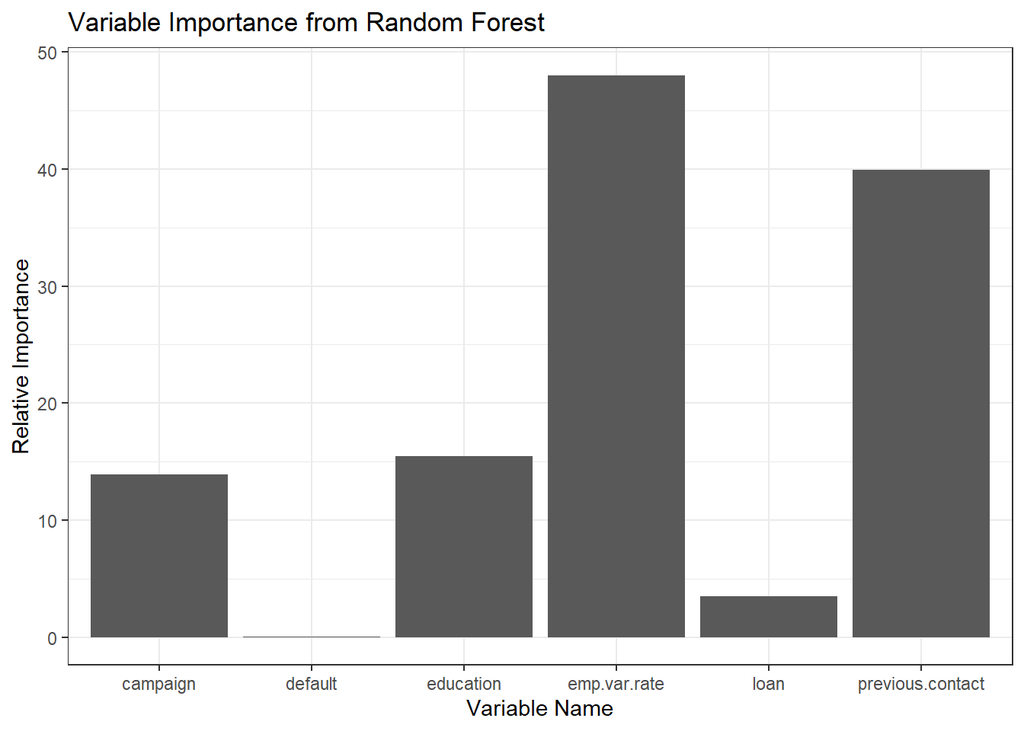

```r
variable_importance.dat %>%
  ggplot(aes(x=var.imp.measures, y=Overall)) +
  theme_bw() +
  geom_bar(stat = "identity") +
  labs(title = "Variable Importance from Random Forest",
       x = "Variable Name", y = "Relative Importance")
```

We can see that similar to the logistic regression model, that the variable emp.var.rate has been given the most importance by the random forest model followed by previous.contact. Default was the variable that was given near 0 importance in weight in contrast to the other variables.

## Predictors for the Logistic Regression and Random Forest Models

It appears that the predictors utilized for the models were insufficient the context of this data for the models used, taking into account the models were being trained on highly imbalanced data. Based on the results though, emp.var.rate and previous.contact were the features given the most significance by the logistic regression and random forest models. For future work the emp.var.rate and previous.contact variables could be retained to see if they contributes to later models that are trained and tested or not. Due to the imbalanced nature of the dataset, the metric Kappa was chosen instead of accuracy alone for evaluating the best fitted cross validation model. This slightly improved overall performance.

## Adaboost Model Composed of All Relevant Variables from Research Question 2

Next is building a boosting model:

```r
set.seed(10)
cluster_1<- makeCluster(3)
registerDoSNOW(cluster_1)
ada.grid = expand.grid(method =c("Adaboost.M1", "Real adaboost"), nIter=c(10:100))
adaboost.trained.1 = train(
     x = bank.3.train_preproc_convert[,-7],
     y = bank.3.train_preproc_convert[,7],
     trControl = trainControl(method="cv",
                             number=10),
     method = "adaboost",
     na.action = na.omit,
     tuneGrid = ada.grid,
     metric="Kappa"
 )
stopCluster(cluster_1)
```

```r
adaboost.trained.1$results %>%
  arrange(desc(Kappa,Accuracy)) %>%
  head(5)
```

```
##        method nIter Accuracy Kappa AccuracySD KappaSD
## 1 Adaboost.M1    41    0.868 0.302     0.0133  0.0836
## 2 Adaboost.M1    40    0.867 0.301     0.0145  0.0850
## 3 Adaboost.M1    42    0.869 0.300     0.0149  0.0963
## 4 Adaboost.M1    17    0.865 0.299     0.0109  0.0599
## 5 Adaboost.M1    20    0.873 0.299     0.0108  0.0763
```

```r
adabost.classif.predict <- predict(adaboost.trained.1,bank.3.test_preproc_convert[,-7])
adaboost_classif_conf.matrix<-
  confusionMatrix(factor(adabost.classif.predict),
                  factor(bank.3.test_preproc_convert[,7]),
                  positive = "yes", mode = "everything")
```

```r
print(adaboost_classif_conf.matrix)
```

```
## Confusion Matrix and Statistics
##
##           Reference
## Prediction  no yes
##        no  758  71
##        yes  65  40
##
##                Accuracy : 0.854
##                  95% CI : (0.83, 0.876)
##     No Information Rate : 0.881
##     P-Value [Acc > NIR] : 0.994
##
##                   Kappa : 0.288
##
##  Mcnemar's Test P-Value : 0.668
##
##             Sensitivity : 0.3604
##             Specificity : 0.9210
##          Pos Pred Value : 0.3810
##          Neg Pred Value : 0.9144
##               Precision : 0.3810
##                  Recall : 0.3604
##                      F1 : 0.3704
##              Prevalence : 0.1188
##          Detection Rate : 0.0428
##    Detection Prevalence : 0.1124
##       Balanced Accuracy : 0.6407
##
##        'Positive' Class : yes
##
```

Below is the variable importance for the Adaboost tree model:

```r
adaboost.var.importance <- varImp(adaboost.trained.1)
adaboost.measurements <- adaboost.var.importance$importance
adaboost.var.imp.measures <-
  row.names(adaboost.measurements)# Getting the names of features
adaboost.variable_importance.dat<-
  data.frame(adaboost.var.imp.measures,
             adaboost.measurements) # putting it all
# together in a single dataframe
row.names(adaboost.variable_importance.dat) = NULL #Eliminating row names
```

```r
print(adaboost.variable_importance.dat)
```

```
##   adaboost.var.imp.measures     no    yes
## 1              emp.var.rate 100.00 100.00
## 2                      loan   3.04   3.04
## 3                   default   0.00   0.00
## 4                 education  19.34  19.34
## 5                  campaign  23.07  23.07
## 6          previous.contact  53.10  53.10
```

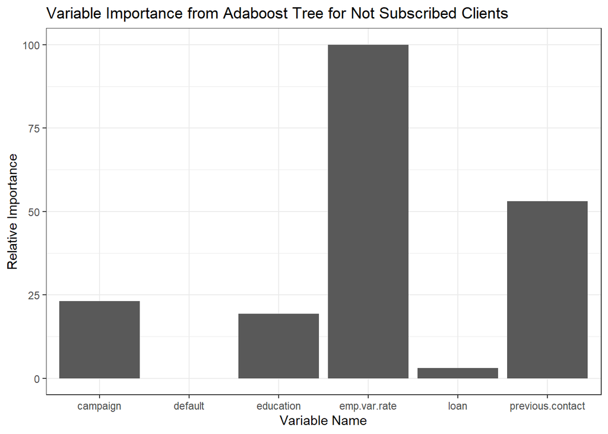

```r
adaboost.variable_importance.dat %>%
  ggplot(aes(x=adaboost.var.imp.measures, y=no)) +
  theme_bw() +
  geom_bar(stat = "identity") +
  labs(title = "Variable Importance from Adaboost Tree for Not Subscribed Clients",
       x = "Variable Name", y = "Relative Importance")
```

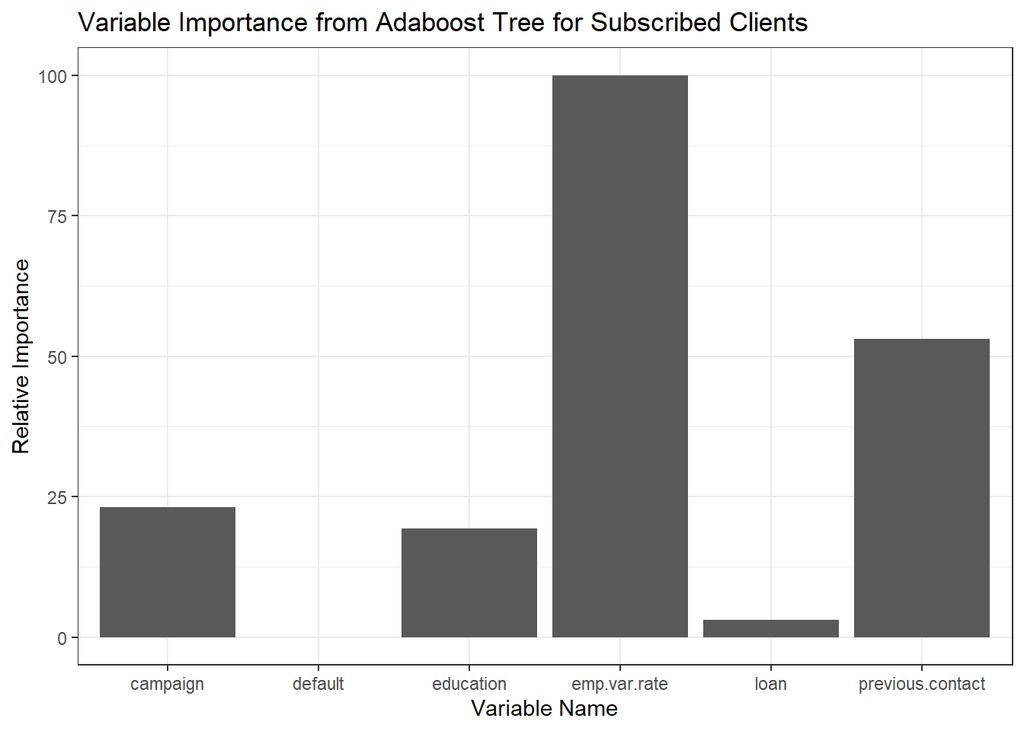

```r
adaboost.variable_importance.dat %>%
  ggplot(aes(x=adaboost.var.imp.measures, y=yes)) +
  theme_bw() +
  geom_bar(stat = "identity") +
  labs(title = "Variable Importance from Adaboost Tree for Subscribed Clients",
       x = "Variable Name", y = "Relative Importance")
```

In the Adaboost tree model, similar to the random forest model before it, emp.var.rate is given the most weight in regard to variable importance followed by previous.contact. There has been a slight shift in the variable importance of campaign and education in contrast to the random forest, where the variable campaign has slightly more weight relative to other variables for the Adaboost tree model. Overall, the Adaboost tree model has reaffirmed the signidicance fo the variables emp.var.rate and previous.contact for model performance.

# Conclusion

## Research Question 1

For research question 1, it appears that job status and default status may have a relationship in the data, but marital status and default status do not seem to be independent. Thus, we reject the null hypothesis in the context of this data that default status is independent of job status and marital status.

## Limitations In Dataset

The dataset has a noticeable class imbalance for the response variables for Research Questions 1 and 2. This can lead to a number of issues when training models such as the models being heavily trained to primarily identify the majority class. Likewise, missing values in Research Question 1 response variable can be observed to have led to less informative results for the broader population of potential clients who might or might not subscribe to the bank’s term deposit product. More complete instances for the data would potentially assist with building more successful models.

## Future Work

For building additional models, more algorithms can be explored. Such algorithms as the Naive Bayes algorithm, potentially the support vector machine algorithm, neural networks, and other algorithms as well. Preferably, algorithms that can address the class imbalance while limiting other issues such as overfitting would be preferred.

Additionally, the library H2O could be used to be able to develop models that are capable of being actively deployed in a compatible cyber ecosystem after successful trainind, validation and testing. Doing so would involve mode computational resources that would also have to be addressed to build models in a time and resource efficient manner.

Ensemble techniques can be explored as well at a later date. Using ensemble methods may present new opportunities and benefits that could not be seen in the base models alone. Once again, if boosting models were to be further explored they would have to be cautiously developed or else they may run into severe overfitting issues that jeopardize the performance of the model.

# Acknowledgements

Thanks to the North Carolina Agricultural and Technical State University Applied Science and Technology Program for accepting me as a PhD student this semester.

Thanks to the UCI Machine Learning Repository for storing and maintaining this data.

Thanks to S. Moro, P. Cortez and P. Rita for their original work and allowing for UCI Machine Learning Repository to store and maintain the data.

Thanks to Dr. Mostafa for an excellent STAT 707: Introduction to Data Science course this semester and an excellent AST 992: Doctoral Seminar in Data Science and Analytics.

Thanks to Dr. Tang, Dr. Kim, and Dr. Mostafa for excellent courses this semester and workshops this semester that have contributed to the growth of my overall knowledge.

Thanks to the classmates that I have had this semester and their encouragement. Thanks to them for providing their experience and thanks for them bringing new knowledge to the discussion each day.

Thanks to the many who have worked on R, are working on R and have provided documentation, workshops, tutorials etc. for R that has given me additional knowledge and tools to employ for this project.

# References

## Data Source

[Moro et al., 2014] S. Moro, P. Cortez and P. Rita. A Data-Driven Approach to Predict the Success of Bank Telemarketing. Decision Support Systems, Elsevier, 62:22-31, June 2014.

Dua, D. and Graff, C. (2019). UCI Machine Learning Repository [http://archive.ics.uci.edu/ml]. Irvine, CA: University of California, School of Information and Computer Science.